# Fifth Week: Bootstrap and Resampling Methods

Fifth Week: Bootstrap and Resampling Methods Nonparametric Hypothesis tests Kayhan Momeni 24 Esfand 1396

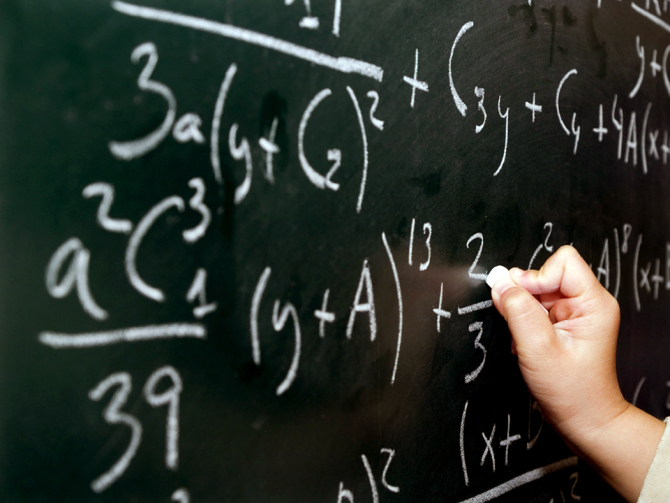

> لطفا به سوالات زیر پاسخ دهید. در همه سوالات سطح دقت را ۹۵ درصد در نظر بگیرید.

ابتدا باید پکیج های مورد نیاز را صدا بزنیم:

```r
library(dplyr)
library(highcharter)
library(coin)
library(readr)
library(tidyr)
library(broom)
```

##### ۱. شرکتی میخواهد تحقیق کند آیا درآمد نمایندگی های آن یکسان است. برای بررسی این موضوع هشت نمایندگی به طور تصادفی انتخاب شده اند که به ترتیب میزان فروش آنها عبارت است از 102, 300, 102, 100, 205, 105, 71 , 92. با توجه به داده آیا عملکرد نمایندگی ها یکسان است؟

###### پاسخ:

نمودار میزان فروش شعبه ها، به این صورت است:

```r
mat = matrix(0, nrow = 8, ncol = 2)
dat = as.data.frame(mat)
dat$V1=1:8
dat$V2=c(102, 300, 102, 100, 205, 105, 71, 92)

hchart(dat, type="column", hcaes(x=V1, y=V2)) %>%
  hc_xAxis(title = list(text = "Branch No.")) %>%
  hc_yAxis(title = list(text = "Sales Amount")) %>%
  hc_add_theme(hc_theme_elementary())
```

[interactive chart not shown]

اگر عملکرد همه ی شعبه ها یکسان بود، باید همه ی ستون ها تقریبا برابر می شد که به نظر می رسد اینگونه نباشد. برای بررسی دقیقتر موضوع، از آزمون Chi-Square Goodness-of-Fit استفاده می کنیم تا ببینیم آیا توزیع ستون ها در نمودار با یکدیگر برابر است یا خیر (تابع توزیع یونیفرم است یا نه):

```r
prob = c(1/8, 1/8, 1/8, 1/8, 1/8, 1/8, 1/8, 1/8)
chisq.test(dat$V2, p=prob)
```

```
##
##  Chi-squared test for given probabilities
##
## data:  dat$V2
## X-squared = 314.74, df = 7, p-value < 2.2e-16
```

همانطور که مشخص است، به خاطر کوچک بودن p-value، فرض صفر (یونیفرم بودن توزیع فروش) رد می شود. بنابراین عملکرد شعبه ها دارای اختلاف آماری معنادار است.

##### ۲. آمار فروش شرکتی در دو نوع شعبه سنتی و مدرن در زیر آمده است. آیا تفاوتی در عملکرد دو نوع شعبه وجود دارد؟

##### Classical stores: 50, 50, 60, 70, 75, 80, 90, 85

##### Modern stores: 55, 75, 80, 90, 105, 65

###### پاسخ:

بیایید ابتدا نگاهی به آمار فروش شعبه ها بیندازیم:

```r
mydata = data.frame(Score = c(50, 50, 60, 70, 75, 80, 90, 85, 55, 75, 80, 90, 105, 65),
                    StoreType = factor(c(rep("Classical",8), rep("Modern",6))))

hchart(mydata, type="column", hcaes(y=Score, group=StoreType)) %>%
  hc_xAxis(title = list(text = "Branch No.")) %>%
  hc_yAxis(title = list(text = "Sales Amount")) %>%
  hc_add_theme(hc_theme_elementary())
```

[interactive chart not shown]

در این سوال، برای تشخیص معناداری تفاوت در میانگین ها، باید از Permutation Test استفاده کنیم. بدین صورت که فرض کنیم هر دو گروه نمونه اعدادی از یک تابع توزیع باشند. بنابراین می توان همه ی آن ها را در یک گروه در نظر گرفت. سپس باید همه ی انتخاب های ۸ تایی از این ۱۴ تا عدد را در نظر گرفت و میانگینشان را حساب کرد. به ازای هر انتخاب، ۶ عدد وجود دارند که انتخاب نشده اند. میانگین آن ها را هم به صورت جدا باید حساب کنیم. سپس اختلاف میانگین هر انتخاب ۸ تایی با گروه ۶ تایی متناظرش را حساب کنیم. این اختلاف ها یک تابع توزیعی دارند. سپس برای داده های اصلی هم در گروه ۸ تایی سنتی و ۶ تایی مدرن میانگین ها را حساب می کنیم و اختلافشان را نگاه می کنیم که در کجای تابع توزیع اختلاف ها قرار دارد. اگر در ۹۵ درصد بازه ی اطمینان وسط بود، نمی توان در خصوص رد فرض صفر حرفی زد. اما اگر در ۲.۵ درصد ابتدا و انتهای تابع توزیع بود، می توان فرض صفر را رد کرد.

خوشبختانه کتابخانه ی coin عملیات بالا را برای ما انجام میدهد:

```r
oneway_test(Score~StoreType, data=mydata, distribution="exact")
```

```
##
##  Exact Two-Sample Fisher-Pitman Permutation Test
##
## data:  Score by StoreType (Classical, Modern)
## Z = -0.94426, p-value = 0.3803
## alternative hypothesis: true mu is not equal to 0
```

با توجه به بالا بودن p-value، نمی توان فرض صفر را رد کرد. یعنی نمی توان نتیجه گرفت که در آمار فروش شعبه های سنتی و مدرن، تفاوت وجود دارد.

##### ۳. اطلاعات حسابداری ۱۵ شعبه که به صورت تصادفی انتخاب شده اند به شرح زیر است:

##### 509, 517, 502, 629, 830, 911, 847, 803, 727, 853, 757, 730, 774, 718, 904

##### شرکت مذکور برای ارتقای فروش خود یک طرح تبلیغاتی جدید را اجرا میکند. پس از طرح جدید نتایج عملکرد شعبه ها به صورت زیر اندازه گیری شده است:

##### 517, 508, 523, 730, 821, 940, 818, 821, 842, 842, 709, 688, 787, 780, 901

##### آیا تبلیغات جدید عملکرد فروش را بالا برده است؟

###### پاسخ:

حل این سوال بسیار مشابه سوال قبل است:

```r
mydata = data.frame(Score = c(509, 517, 502, 629, 830, 911, 847, 803, 727, 853, 757, 730, 774, 718, 904,
                              517, 508, 523, 730, 821, 940, 818, 821, 842, 842, 709, 688, 787, 780, 901),
                    Type = factor(c(rep("Before the Advertisement",15), rep("After the Advertisement",15))))

hchart(mydata, type="column", hcaes(y=Score, group=Type)) %>%
  hc_xAxis(title = list(text = "Branch No.")) %>%
  hc_yAxis(title = list(text = "Sales Amount")) %>%
  hc_add_theme(hc_theme_elementary())
```

[interactive chart not shown]

```r
oneway_test(Score~Type, data=mydata, distribution="exact")
```

```
##
##  Exact Two-Sample Fisher-Pitman Permutation Test
##
## data:  Score by
##   Type (After the Advertisement, Before the Advertisement)
## Z = 0.2915, p-value = 0.7758
## alternative hypothesis: true mu is not equal to 0
```

در اینجا هم نمی توان تفاوت معناداری در عملکرد شعب پیش و پس از تبلیغات مشاهده کرد.

##### ۴. محصولی در سه رنگ سفید آبی و قرمز تولید شده است. پنج شعبه از فروشگاه سازنده محصول به صورت تصادفی انتخاب شده و اطلاعات فروش آنها در زیر آمده است.

| Store | White | Blue | Red |
| --- | --- | --- | --- |
| 1. | 510 | 925 | 730 |
| 2. | 720 | 735 | 745 |
| 3. | 930 | 753 | 875 |
| 4. | 754 | 685 | 610 |
| 5. | 105 |  |  |

##### با توجه به داده های بالا آیا رنگی خاص در میزان فروش محصولات تاثیر دارد؟

###### پاسخ:

میانگین فروش هر رنگ به صورت زیر است:

```r
mydata = data.frame(Score = c(510, 720, 930, 754, 105,
                              925, 735, 753, 685,
                              730, 745, 875, 610),
                    Color = factor(c(rep("White",5), rep("Blue",4), rep("Red",4))))
mydata %>%
  group_by(Color) %>%
  summarise(Score = mean(Score)) -> dat

hchart(dat, type="column", hcaes(x=Color, y=Score)) %>%
  hc_xAxis(title = list(text = "Color")) %>%
  hc_yAxis(title = list(text = "Average Sales Amount")) %>%
  hc_add_theme(hc_theme_elementary())
```

[interactive chart not shown]

برای تعیین اینکه آیا تفاوت در میانگین ها معنادار است یا خیر، از آزمون Kruskal-Wallis استفاده می کنیم:

```r
kruskal_test(Score~Color, data=mydata)
```

```
##
##  Asymptotic Kruskal-Wallis Test
##
## data:  Score by Color (Blue, Red, White)
## chi-squared = 0.47473, df = 2, p-value = 0.7887
```

همانطور که مشخص است، نمی توان از طریق این آزمون، تفاوت معناداری در میزان فروش گروه های رنگی مختلف نتیجه گرفت.

##### ۵. یک موسسه نظرسنجی نظرات مردم در مورد رضایت از یک محصول که در ماه های فروردین اردیبهشت خرداد و تیر که از طریق تلویزیون تبلیغ شده است را مورد ارزیابی قرار می دهد.این کار بدین صورت است از افرادی در ماه اول سوال پرسیده می شود و در ماه آینده نیز از همان فرد سوال می شود که آیا از محصول مذکور راضی هستی یا خیر. با توجه به داده ایی که در پیوست تمرین آمده است آیا تبلیغات تاثیر مثبتی در افزایش رضایت مردم داشته است؟

###### پاسخ:

ابتدا بد نیست به درصد افراد راضی از محصول در هر ماه نگاهی بیندازیم:

```r
tv = read_csv("/Users/kayhan/Desktop/tv.csv")
```

```r
tv %>%
  mutate(tmp = 1, PersonID = cumsum(tmp)) %>%
  select(PersonID, March, April, May, Jun) -> tv

tv %>%
  gather(Month, Idea, -PersonID) -> mydata

tv %>%
  select(March, April, May, Jun) ->tv

mydata%>%
  group_by(Month) %>%
  summarise(satisfied = sum(Idea==1)*100/15) -> stat

stat$Month <- factor(stat$Month, levels=c("March", "April", "May", "Jun"))

stat %>%
  arrange(Month) ->stat

hchart(stat, type="column", hcaes(x=Month, y=satisfied)) %>%
  hc_xAxis(title = list(text = "Month")) %>%
  hc_yAxis(title = list(text = "Percentage of Satisfied People")) %>%
  hc_add_theme(hc_theme_elementary())
```

[interactive chart not shown]

حالا می خواهیم ببینیم افزایش رضایت در ماه Jun معنادار بوده است یا خیر. برای این منظور، چون با یک مسئله ی اندازه گیری های تکرار شونده روبروییم و می خواهیم آزمون غیر پارامتری مناسب را اجرا کنیم، از آزمون Friedman استفاده می کنیم:

```r
friedman.test(as.matrix(tv))
```

```
##
##  Friedman rank sum test
##
## data:  as.matrix(tv)
## Friedman chi-squared = 1.2, df = 3, p-value = 0.753
```

چون p-value بزرگ است، نمی توان فرض صفر را رد کرد. یعنی نمی توان نتیجه گرفت که تبلیغات تاثیر معناداری داشته است.

##### ۶. شرکتی در حال تحقیق بر روی این موضوع است که آیا جمعیت شهر تاثیری در نوع میزان مصرف محصولات شرکت دارد. با توجه به داده زیر این موضوع را تحقیق کنید؟

| City size |  | Frequency of service usage |  |
| --- | --- | --- | --- |
|  | Always | Sometime | Never |
| Small | 151 | 252 | 603 |
| Medium | 802 | 603 | 405 |
| Large | 753 | 55 | 408 |

###### پاسخ:

ابتدا به نمودار تعداد داده ها نگاه کنیم:

```r
mydata = matrix(c(151, 802, 753, 252, 603, 55, 603, 405, 408), nrow=3, ncol=3)
colnames (mydata) <- c("Always", "Sometime", "Never")
rownames (mydata) <- c("Small", "Medium", "Large")

hchart(mydata) %>%
  hc_xAxis(title = list(text = "Frequency of Service Usage")) %>%
  hc_yAxis(title = list(text = "City Size")) %>%
  hc_add_theme(hc_theme_elementary())
```

[interactive chart not shown]

می توان به جای رنگ، از ویژگی مساحت هم برای نشان دادن مقدار هر مربع استفاده کرد:

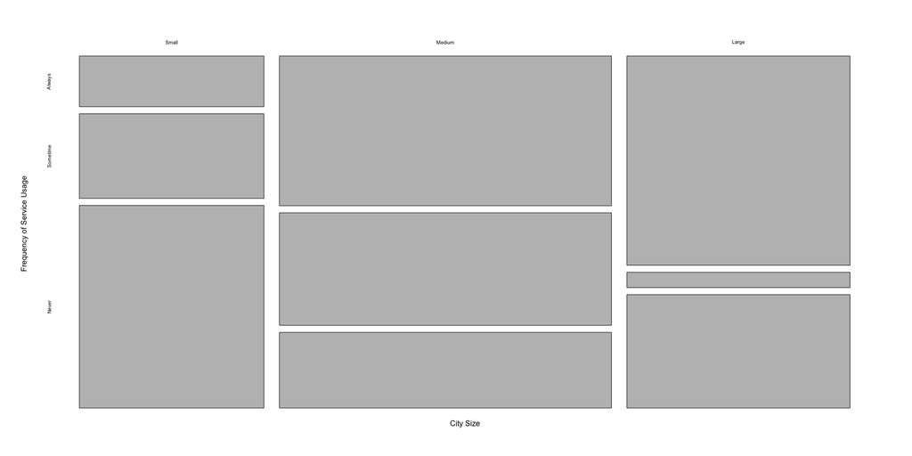

```r
plot(as.table(mydata), xlab="City Size", ylab="Frequency of Service Usage", main="")
```

به نظر می رسد که دو متغیر به یکدیگر وابسته اند. برای آزمون آماری این قضیه، از آزمون Chi-squared Test of Independence استفاده می کنیم:

```r
chisq.test(mydata)
```

```
##
##  Pearson's Chi-squared test
##
## data:  mydata
## X-squared = 821.31, df = 4, p-value < 2.2e-16
```

همانطور که مشخص است، به خاطر کوچک بودن p-value، فرض استقلال متغیر ها رد می شود. بنابر این متغیر ها به یکدیگر وابسته اند.

##### ۷. شرکتی انتظار دارد با ارایه محصول الف میزان فروش محصول ب افزایش یابد. به همین منظور به طور تصادفی از صد مشتری خود اطلاعات مصرف جمع آوری می نماید. با توجه به داده های که داده شده آیا ربط معناداری بین فروش این دو محصول وجود دارد؟

###### پاسخ:

بیایید در ابتدا نگاهی به نمودار میزان مصرف محصول ب بر حسب میزان مصرف محصول الف بیندازیم:

```r
consumption = read_csv("/Users/kayhan/Desktop/consumption.csv")
```

```r
modlss <- loess(B~A, data = consumption)
fit <- augment(modlss) %>% arrange(A)

hchart(consumption, type="scatter", hcaes(x=A, y=B)) %>%
  hc_add_series(fit, type = "spline", hcaes(x = A, y = .fitted), name = "Fit", id = "fit") %>%
  hc_add_series(fit, type = "arearange", hcaes(x = A, low = .fitted - 2*.se.fit,
                                               high = .fitted + 2*.se.fit),
                linkedTo = "fit") %>%
  hc_xAxis(title = list(text = "Usage of A")) %>%
  hc_yAxis(title = list(text = "Usage of B")) %>%
  hc_add_theme(hc_theme_elementary())
```

[interactive chart not shown]

به نظر میرسد که همبستگی بین میزان مصرف محصول الف و ب وجود ندارد. برای سنجش آماری این امر، از تست Spearman Correlation استفاده می کنیم:

```r
cor(consumption$A, consumption$B, method = "spearman")
```

```
## [1] 0.03736654
```

همانطور که مشخص است، میزان همبستگی بسیار پایین است و میزان مصرف محصول الف، تاثیری روی میزان مصرف محصول ب ندارد.

##### ۸. یک شرکت از ۲۰۰۰ نفر از مشتریان خود عامل خرید محصول را مورد سوال قرار میدهد که خلاصه اطلاعات آن را در زیر می توانید مشاهده کنید

| Characteristics | Male | Female |
| --- | --- | --- |
| Price | 301 | 502 |
| Design | 353 | 155 |
| Color | 558 | 153 |

##### آیا جنسیت تاثیری در مشخصه کاربری کالا دارد؟

###### پاسخ:

حل این سوال بسیار مشابه سوال ۶ است. ابتدا به نمودار تعداد داده ها نگاه کنیم:

```r
mydata = matrix(c(301, 353, 558, 502, 155, 153), nrow=3, ncol=2)
colnames (mydata) <- c("Male", "Female")
rownames (mydata) <- c("Price", "Design", "Color")

hchart(mydata) %>%
  hc_xAxis(title = list(text = "Gender")) %>%
  hc_yAxis(title = list(text = "Characteristics")) %>%
  hc_add_theme(hc_theme_elementary())
```

[interactive chart not shown]

می توان به جای رنگ، از ویژگی مساحت هم برای نشان دادن مقدار هر مربع استفاده کرد:

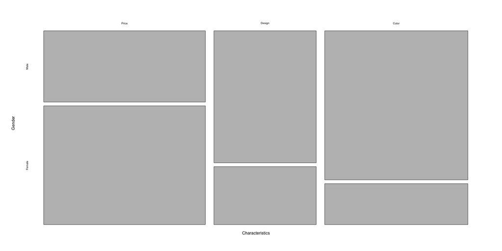

```r
plot(as.table(mydata), xlab="Characteristics", ylab="Gender", main="")
```

به نظر می رسد که دو متغیر به یکدیگر وابسته اند. برای آزمون آماری این قضیه، از آزمون Chi-squared Test of Independence استفاده می کنیم:

```r
chisq.test(mydata)
```

```
##
##  Pearson's Chi-squared test
##
## data:  mydata
## X-squared = 289.71, df = 2, p-value < 2.2e-16
```

همانطور که مشخص است، به خاطر کوچک بودن p-value، فرض استقلال متغیر ها رد می شود. بنابر این متغیر ها به یکدیگر وابسته اند. یعنی عامل خرید محصول به جنسیت وابسته است.